# Energy Analysis

### Is it air temperature, humidity, air movement? Other stuff?

Let's use box plots to investigate!

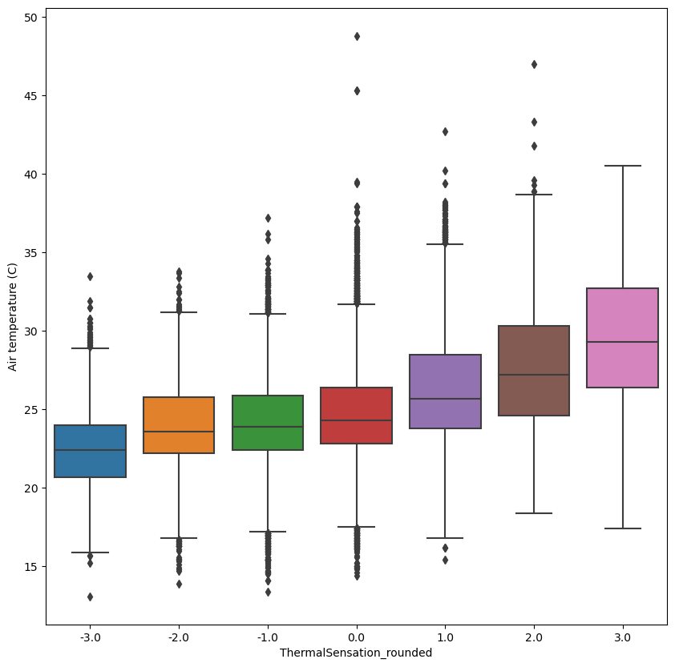

```python
fig, ax = plt.subplots()
# the size of A4 paper
fig.set_size_inches(10,10)
sns.boxplot(x="ThermalSensation_rounded", y="Air temperature (C)", data=ashrae_data)
```

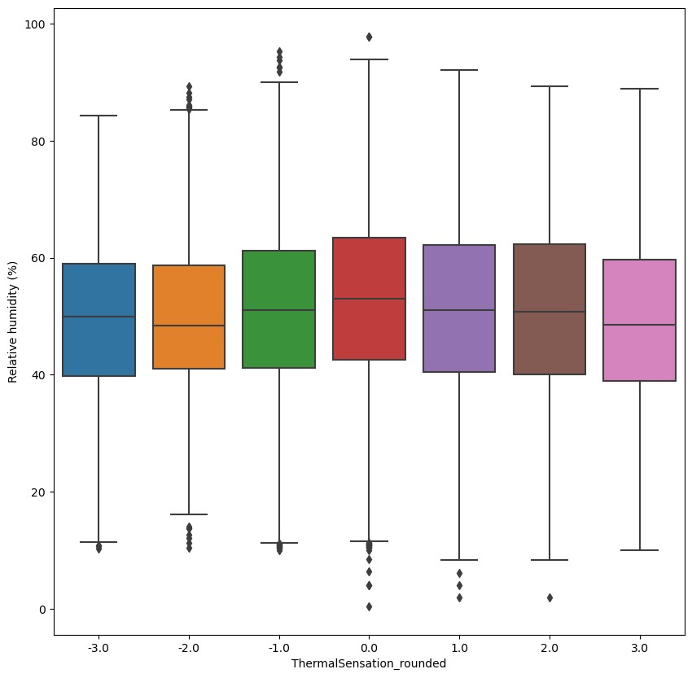

```python
fig, ax = plt.subplots()
# the size of A4 paper
fig.set_size_inches(10,10)
sns.boxplot(data=ashrae_data, x="ThermalSensation_rounded", y="Relative humidity (%)")
```

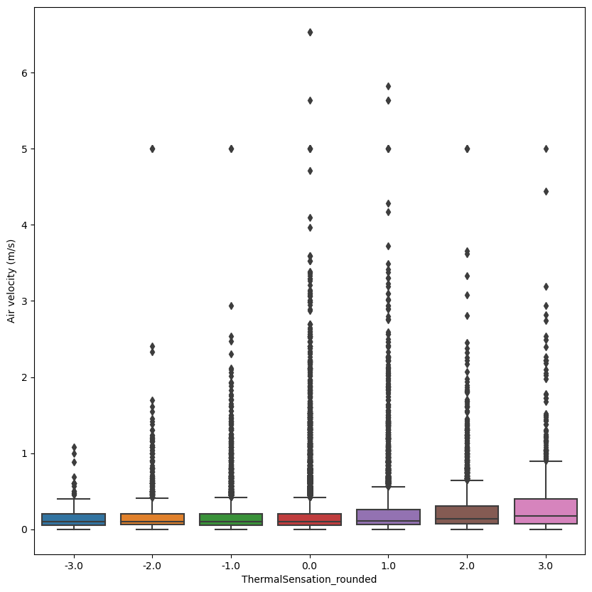

```python
fig, ax = plt.subplots()
# the size of A4 paper
fig.set_size_inches(10,10)
sns.boxplot(data=ashrae_data, x="ThermalSensation_rounded", y="Air velocity (m/s)")
```

### Does personal attributes have an impact?

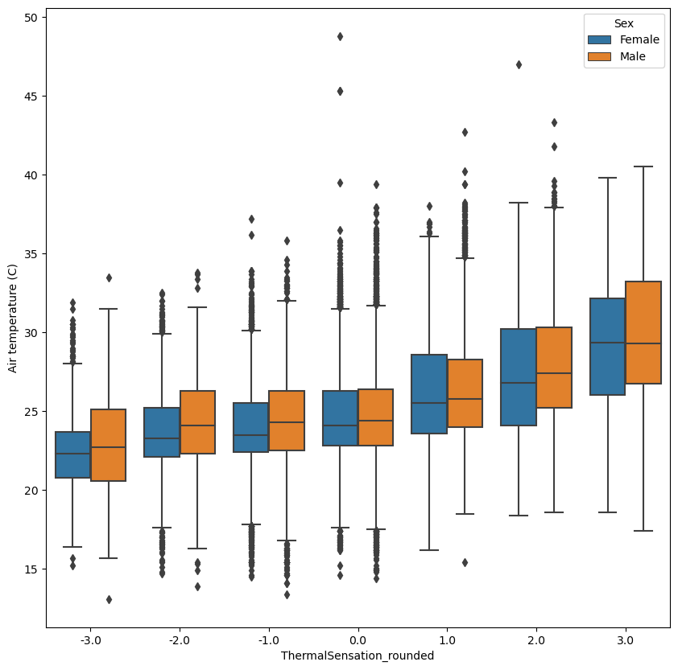

```python
fig, ax = plt.subplots()
# the size of A4 paper
fig.set_size_inches(10,10)
sns.boxplot( data=ashrae_data, x="ThermalSensation_rounded", y="Air temperature (C)", hue="Sex")
```

```python
ashrae_data["Met_rounded"]= ashrae_data["Met"].round(0)
ashrae_data["Clo_rounded"]= ashrae_data["Clo"].round(0)
```

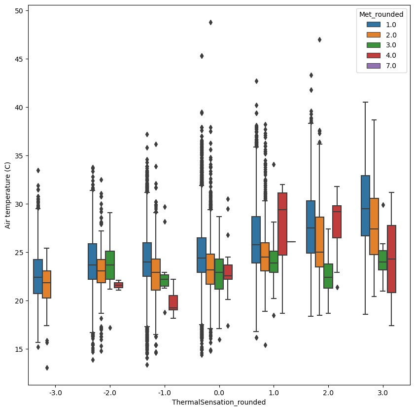

```python
fig, ax = plt.subplots()
# the size of A4 paper
fig.set_size_inches(10,10)
sns.boxplot(data=ashrae_data, x="ThermalSensation_rounded", y="Air temperature (C)", hue="Met_rounded")
```

### How does building type or its systems influence people's comfort?

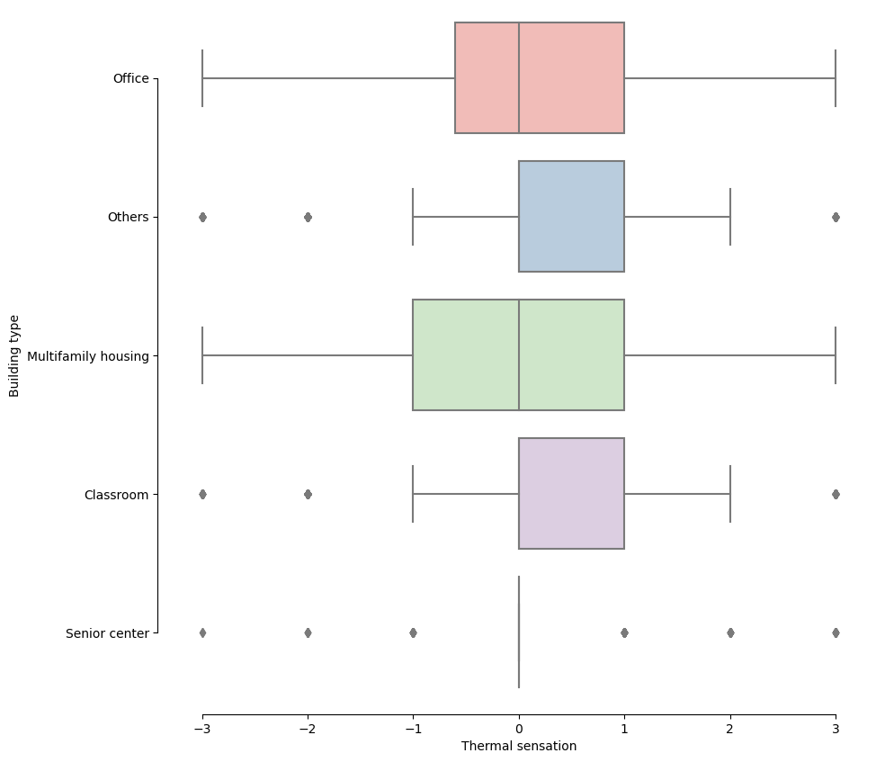

```python
fig, ax = plt.subplots()
# the size of A4 paper
fig.set_size_inches(10,10)
sns.boxplot(y="Building type", x="Thermal sensation",
             palette="Pastel1",
            data=ashrae_data[["Building type","Thermal sensation","Sex"]].dropna())

sns.despine(offset=10, trim=True)
```

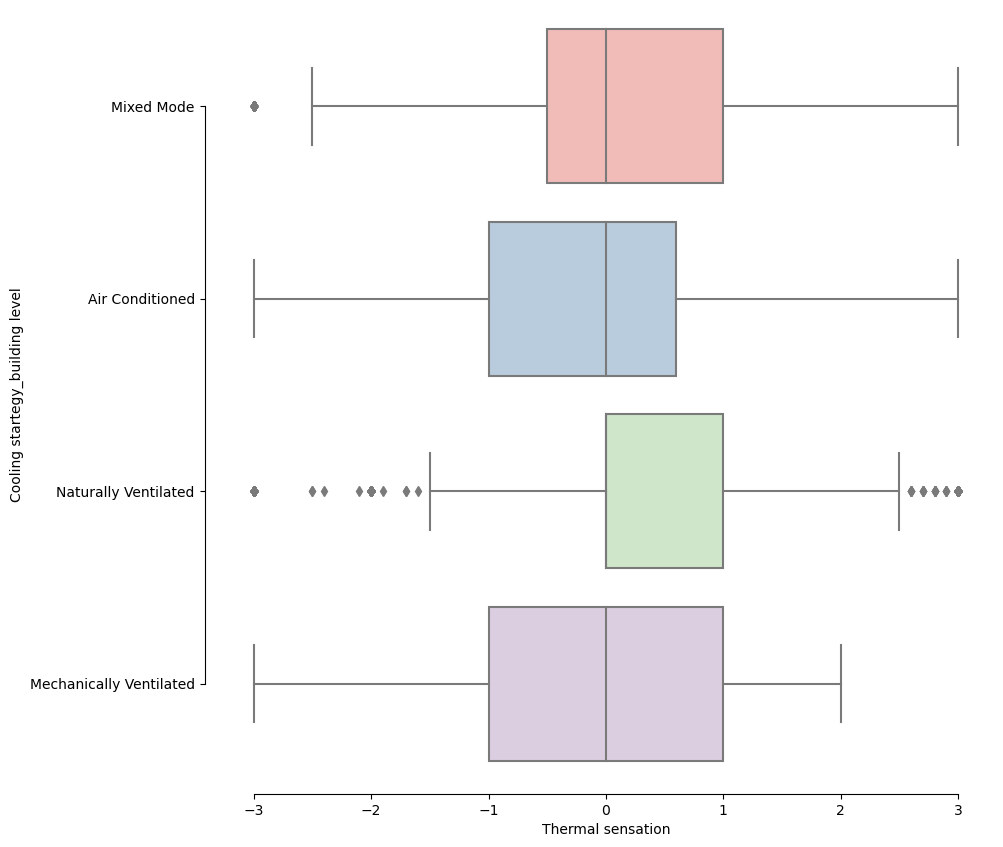

```python
fig, ax = plt.subplots()
# the size of A4 paper
fig.set_size_inches(10,10)
sns.boxplot(y="Cooling startegy_building level", x="Thermal sensation",
             palette="Pastel1",
            data=ashrae_data[["Cooling startegy_building level","Thermal sensation"]].dropna())

sns.despine(offset=10, trim=True)
```

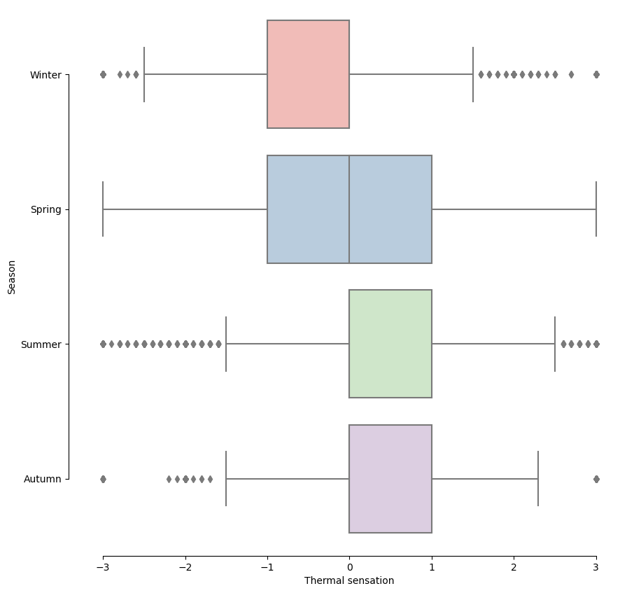

```python
fig, ax = plt.subplots()
# the size of A4 paper
fig.set_size_inches(10,10)
sns.boxplot(y="Season", x="Thermal sensation",
             palette="Pastel1",
            data=ashrae_data[["Season","Thermal sensation"]].dropna())

sns.despine(offset=10, trim=True)
```

### How does people from different country perceive comfort?

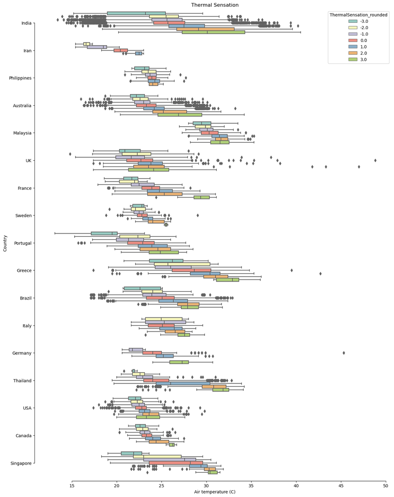

```python
fig, ax = plt.subplots()
# the size of A4 paper
fig.set_size_inches(15,20)
sns.boxplot(y="Country", x="Air temperature (C)",
            hue="ThermalSensation_rounded", palette="Set3",
            data=ashrae_data[["Country","Air temperature (C)","ThermalSensation_rounded"]].dropna())
plt.title("Thermal Sensation")
sns.despine(offset=10, trim=True)
```

# Machine Learning Model

Unsupervised Learning using Clustering and Supervised Prediction using Regression

### Building Data Genome Project Data Set for Clustering and Regression Prediction

```python
import numpy as np
import pandas as pd
import matplotlib.pyplot as plt
import sklearn
from sklearn import metrics
from sklearn.neighbors import KNeighborsRegressor
from scipy.cluster.vq import kmeans, vq, whiten
from scipy.spatial.distance import cdist
from datetime import datetime
```

```python
df = pd.read_csv('./meter_data/Office_Amelia.csv', index_col = "timestamp", parse_dates=True)
```

```python
df.head()
```

| timestamp | Office_Amelia |
| --- | --- |
| 2015-01-01 00:00:00 | 3.96 |
| 2015-01-01 01:00:00 | 4.44 |
| 2015-01-01 02:00:00 | 4.82 |
| 2015-01-01 03:00:00 | 4.28 |
| 2015-01-01 04:00:00 | 18.79 |

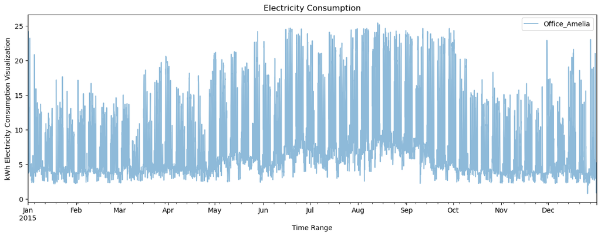

```python
df.plot(alpha=0.5, figsize=(15, 5))
plt.title("Electricity Consumption")
plt.xlabel("Time Range")
plt.ylabel("kWh Electricity Consumption Visualization");
```

```python
df.index[0]
```

```
Timestamp('2015-01-01 00:00:00')
```

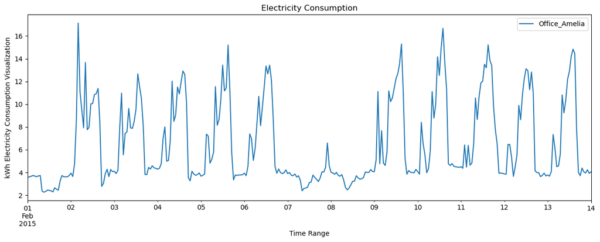

```python
df.truncate(before='2015-02-01', after='2015-02-14').plot(figsize=(15,5))
plt.title("Electricity Consumption")
plt.xlabel("Time Range")
plt.ylabel("kWh Electricity Consumption Visualization");
```

### Daily Profile Analysis - Weekday vs. Weekend¶

```python
df['Date'] = df.index.map(lambda t: t.date())
df['Time'] = df.index.map(lambda t: t.time())
```

```python
df.head()
```

| timestamp | Office_Amelia | Date | Time |
| --- | --- | --- | --- |
| 2015-01-01 00:00:00 | 3.96 | 2015-01-01 | 00:00:00 |
| 2015-01-01 01:00:00 | 4.44 | 2015-01-01 | 01:00:00 |
| 2015-01-01 02:00:00 | 4.82 | 2015-01-01 | 02:00:00 |
| 2015-01-01 03:00:00 | 4.28 | 2015-01-01 | 03:00:00 |
| 2015-01-01 04:00:00 | 18.79 | 2015-01-01 | 04:00:00 |

```python
df_pivot = pd.pivot_table(df, values='Office_Amelia', index='Date', columns='Time')
df_pivot.head()
```

| Time Date | 00:00:00 | 01:00:00 | 02:00:00 | 03:00:00 | 04:00:00 | 05:00:00 | 06:00:00 | 07:00:00 | 08:00:00 | 09:00:00 | ... | 14:00:00 | 15:00:00 | 16:00:00 | 17:00:00 | 18:00:00 | 19:00:00 | 20:00:00 | 21:00:00 | 22:00:00 | 23:00:00 |
| --- | --- | --- | --- | --- | --- | --- | --- | --- | --- | --- | --- | --- | --- | --- | --- | --- | --- | --- | --- | --- | --- |
| 2015-01-01 | 3.96 | 4.44 | 4.82 | 4.28 | 18.79 | 24.16 | 22.65 | 17.08 | 12.46 | 13.24 | ... | 3.72 | 4.82 | 6.15 | 5.47 | 4.97 | 5.93 | 6.46 | 4.67 | 4.50 | 3.98 |
| 2015-01-02 | 4.55 | 4.79 | 4.03 | 4.71 | 19.15 | 23.07 | 23.19 | 21.89 | 16.67 | 9.60 | ... | 3.76 | 3.26 | 3.83 | 4.47 | 3.81 | 3.58 | 3.79 | 4.09 | 4.22 | 4.22 |
| 2015-01-03 | 4.46 | 4.20 | 4.14 | 4.70 | 4.49 | 4.20 | 5.07 | 4.88 | 3.71 | 2.93 | ... | 2.38 | 2.51 | 2.72 | 3.06 | 4.03 | 3.78 | 3.80 | 4.17 | 4.22 | 4.35 |
| 2015-01-04 | 4.50 | 4.47 | 3.95 | 4.61 | 4.48 | 4.34 | 5.15 | 6.26 | 3.69 | 2.97 | ... | 2.40 | 2.39 | 2.60 | 2.90 | 3.47 | 3.50 | 4.24 | 4.01 | 3.99 | 3.73 |
| 2015-01-05 | 4.06 | 3.93 | 4.08 | 4.66 | 20.83 | 20.00 | 16.80 | 16.64 | 15.47 | 11.35 | ... | 11.34 | 11.08 | 8.79 | 3.27 | 3.78 | 3.56 | 3.84 | 4.00 | 3.79 | 3.73 |

5 rows × 24 columns

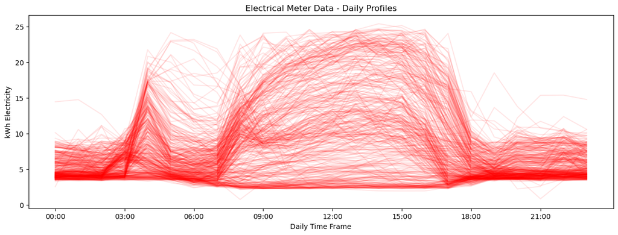

```python
df_pivot.T.plot(legend=False, figsize=(15,5), color='r', alpha=0.1, xticks=np.arange(0, 86400, 10800))
plt.title("Electrical Meter Data - Daily Profiles")
plt.xlabel("Daily Time Frame")
plt.ylabel("kWh Electricity");
```

Let's look at weekdays first:

```python
test = df.index[0].date()
test.weekday()
```

```
3
```

```python
df['Weekday'] = df.index.map(lambda t: t.date().weekday())
```

```python
df.head()
```

| timestamp | Office_Amelia | Date | Time | Weekday |
| --- | --- | --- | --- | --- |
| 2015-01-01 00:00:00 | 3.96 | 2015-01-01 | 00:00:00 | 3 |
| 2015-01-01 01:00:00 | 4.44 | 2015-01-01 | 01:00:00 | 3 |
| 2015-01-01 02:00:00 | 4.82 | 2015-01-01 | 02:00:00 | 3 |
| 2015-01-01 03:00:00 | 4.28 | 2015-01-01 | 03:00:00 | 3 |
| 2015-01-01 04:00:00 | 18.79 | 2015-01-01 | 04:00:00 | 3 |

```python
df_pivot_weekday = pd.pivot_table(df[(df.Weekday < 5)], values='Office_Amelia', index='Date', columns='Time')
```

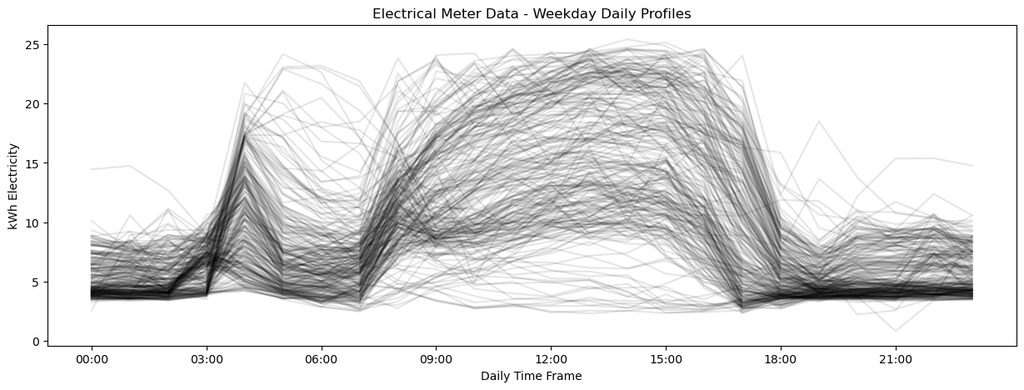

```python
df_pivot_weekday.T.plot(legend=False, figsize=(15,5), color='k', alpha=0.1, xticks=np.arange(0, 86400, 10800))
plt.title("Electrical Meter Data - Weekday Daily Profiles")
plt.xlabel("Daily Time Frame")
plt.ylabel("kWh Electricity");
```

### Manual indentification of clusters

There is varying levels of consumption throughout the course of a year. This is probably because of weather effects or schedule changes.

Let's try weekend:

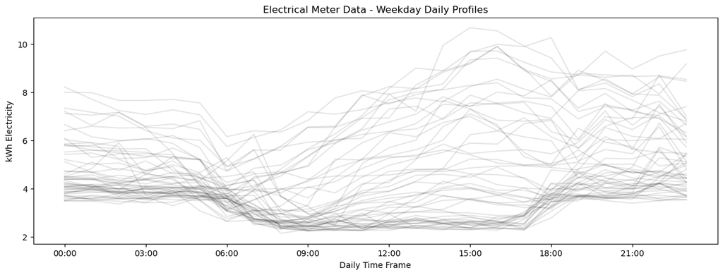

```python
df_pivot_weekend = pd.pivot_table(df[(df.Weekday > 5)], values='Office_Amelia', index='Date', columns='Time')
df_pivot_weekend.T.plot(legend=False, figsize=(15,5), color='k', alpha=0.1, xticks=np.arange(0, 86400, 10800))
plt.title("Electrical Meter Data - Weekday Daily Profiles")
plt.xlabel("Daily Time Frame")
plt.ylabel("kWh Electricity");
```

### K-means clusdering - daily load profile

```python
df = pd.read_csv('./meter_data/Office_Amelia.csv', index_col = "timestamp", parse_dates=True)
```

```python
df_norm = (df - df.mean()) / (df.max() - df.min())

df['Time'] = df.index.map(lambda t: t.time())
df['Date'] = df.index.map(lambda t: t.date())
df_norm['Time'] = df_norm.index.map(lambda t: t.time())
df_norm['Date'] = df_norm.index.map(lambda t: t.date())
```

```python
dailyblocks = pd.pivot_table(df, values='Office_Amelia', index='Date', columns='Time', aggfunc='mean')
dailyblocks_norm = pd.pivot_table(df_norm, values='Office_Amelia', index='Date', columns='Time', aggfunc='mean')
```

### Clustering Model

```python
dailyblocksmatrix_norm = np.matrix(dailyblocks_norm.dropna())
centers, _ = kmeans(dailyblocksmatrix_norm, 4, iter=10000)
cluster, _ = vq(dailyblocksmatrix_norm, centers)
```

```python
clusterdf = pd.DataFrame(cluster, columns=['ClusterNo'])
```

```python
dailyclusters = pd.concat([dailyblocks.dropna().reset_index(), clusterdf], axis=1)
```

```python
dailyclusters.head()
```

|  | Date | 00:00:00 | 01:00:00 | 02:00:00 | 03:00:00 | 04:00:00 | 05:00:00 | 06:00:00 | 07:00:00 | 08:00:00 | ... | 15:00:00 | 16:00:00 | 17:00:00 | 18:00:00 | 19:00:00 | 20:00:00 | 21:00:00 | 22:00:00 | 23:00:00 | ClusterNo |
| --- | --- | --- | --- | --- | --- | --- | --- | --- | --- | --- | --- | --- | --- | --- | --- | --- | --- | --- | --- | --- | --- |
| 0 | 2015-01-01 | 3.96 | 4.44 | 4.82 | 4.28 | 18.79 | 24.16 | 22.65 | 17.08 | 12.46 | ... | 4.82 | 6.15 | 5.47 | 4.97 | 5.93 | 6.46 | 4.67 | 4.50 | 3.98 | 3 |
| 1 | 2015-01-02 | 4.55 | 4.79 | 4.03 | 4.71 | 19.15 | 23.07 | 23.19 | 21.89 | 16.67 | ... | 3.26 | 3.83 | 4.47 | 3.81 | 3.58 | 3.79 | 4.09 | 4.22 | 4.22 | 3 |
| 2 | 2015-01-03 | 4.46 | 4.20 | 4.14 | 4.70 | 4.49 | 4.20 | 5.07 | 4.88 | 3.71 | ... | 2.51 | 2.72 | 3.06 | 4.03 | 3.78 | 3.80 | 4.17 | 4.22 | 4.35 | 0 |
| 3 | 2015-01-04 | 4.50 | 4.47 | 3.95 | 4.61 | 4.48 | 4.34 | 5.15 | 6.26 | 3.69 | ... | 2.39 | 2.60 | 2.90 | 3.47 | 3.50 | 4.24 | 4.01 | 3.99 | 3.73 | 0 |
| 4 | 2015-01-05 | 4.06 | 3.93 | 4.08 | 4.66 | 20.83 | 20.00 | 16.80 | 16.64 | 15.47 | ... | 11.08 | 8.79 | 3.27 | 3.78 | 3.56 | 3.84 | 4.00 | 3.79 | 3.73 | 3 |

5 rows × 26 columns

```python
x = dailyclusters.groupby('ClusterNo').mean(numeric_only=True).sum(axis=1).sort_values()
x = pd.DataFrame(x.reset_index())
x['ClusterNo2'] = x.index
x = x.set_index('ClusterNo')
x = x.drop([0], axis=1)
dailyclusters = dailyclusters.merge(x, how='outer', left_on='ClusterNo', right_index=True)
```

```python
dailyclusters = dailyclusters.drop(['ClusterNo'],axis=1)
dailyclusters = dailyclusters.set_index(['ClusterNo2','Date']).T.sort_index()
```

```python
dailyclusters.head()
```

| ClusterNo2 Date | 1 2015-01-01 | 1 2015-01-02 | 1 2015-01-05 | 1 2015-01-06 | 1 2015-01-07 | 1 2015-01-08 | 1 2015-01-09 | 1 2015-01-12 | 1 2015-01-13 | 1 2015-01-14 | ... | 3 2015-09-17 | 3 2015-09-21 | 3 2015-09-22 | 3 2015-09-23 | 3 2015-09-24 | 3 2015-09-25 | 3 2015-09-28 | 3 2015-09-29 | 3 2015-09-30 | 3 2015-10-01 |
| --- | --- | --- | --- | --- | --- | --- | --- | --- | --- | --- | --- | --- | --- | --- | --- | --- | --- | --- | --- | --- | --- |
| 00:00:00 | 3.96 | 4.55 | 4.06 | 3.25 | 4.61 | 4.42 | 4.62 | 4.05 | 4.59 | 4.12 | ... | 4.09 | 4.59 | 5.11 | 4.71 | 4.93 | 5.63 | 4.57 | 5.60 | 5.90 | 4.89 |
| 01:00:00 | 4.44 | 4.79 | 3.93 | 3.65 | 4.31 | 5.01 | 4.95 | 4.71 | 4.60 | 4.48 | ... | 4.97 | 4.88 | 10.58 | 4.74 | 5.50 | 5.72 | 5.20 | 5.38 | 5.26 | 5.56 |
| 02:00:00 | 4.82 | 4.03 | 4.08 | 4.04 | 3.98 | 4.18 | 4.98 | 4.48 | 4.71 | 4.69 | ... | 6.18 | 5.75 | 7.18 | 4.31 | 4.44 | 5.07 | 4.18 | 4.79 | 5.20 | 5.57 |
| 03:00:00 | 4.28 | 4.71 | 4.66 | 4.20 | 4.99 | 5.67 | 5.10 | 7.35 | 6.75 | 9.79 | ... | 5.14 | 4.99 | 4.78 | 4.26 | 4.90 | 5.64 | 4.68 | 5.36 | 5.21 | 4.51 |
| 04:00:00 | 18.79 | 19.15 | 20.83 | 15.90 | 13.89 | 6.63 | 13.67 | 9.57 | 7.78 | 12.37 | ... | 9.50 | 19.93 | 10.67 | 8.44 | 10.04 | 11.30 | 17.25 | 10.35 | 10.88 | 9.69 |

5 rows × 365 columns

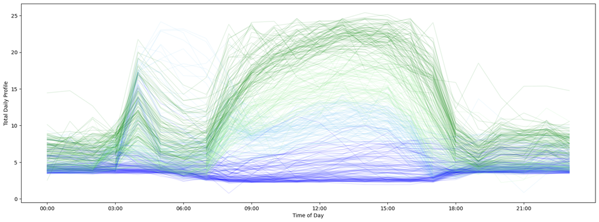

```python
clusterlist = list(dailyclusters.columns.get_level_values(0).unique())
matplotlib.rcParams['figure.figsize'] = 20, 7

styles2 = ['LightSkyBlue', 'b','LightGreen', 'g','LightCoral','r','SandyBrown','Orange','Plum','Purple','Gold','b']
fig, ax = plt.subplots()
for col, style in zip(clusterlist, styles2):
    dailyclusters[col].plot(ax=ax, legend=False, style=style, alpha=0.1, xticks=np.arange(0, 86400, 10800))

ax.set_ylabel('Total Daily Profile')
ax.set_xlabel('Time of Day');
```

### Aggregate visualizations of the clusters

```python
def timestampcombine(date,time):
    pydatetime = datetime.combine(date, time)
    return pydatetime
```

```python
def ClusterUnstacker(df):
    df = df.unstack().reset_index()
    df['timestampstring'] = pd.to_datetime(df.Date.astype("str") + " " + df.level_2.astype("str"))
    #pd.to_datetime(df.Date  df.level_2) #map(timestampcombine, )
    df = df.dropna()
    return df
```

```python
dailyclusters.unstack().reset_index().head()
```

|  | ClusterNo2 | Date | level_2 | 0 |
| --- | --- | --- | --- | --- |
| 0 | 1 | 2015-01-01 | 00:00:00 | 3.96 |
| 1 | 1 | 2015-01-01 | 01:00:00 | 4.44 |
| 2 | 1 | 2015-01-01 | 02:00:00 | 4.82 |
| 3 | 1 | 2015-01-01 | 03:00:00 | 4.28 |
| 4 | 1 | 2015-01-01 | 04:00:00 | 18.79 |

```python
dfclusterunstacked = ClusterUnstacker(dailyclusters)
dfclusterunstackedpivoted = pd.pivot_table(dfclusterunstacked, values=0, index='timestampstring', columns='ClusterNo2')
```

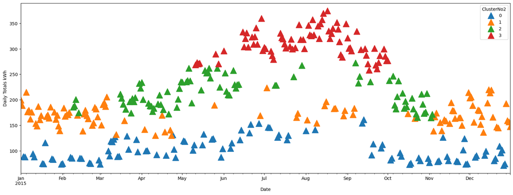

```python
clusteravgplot = dfclusterunstackedpivoted.resample('D').sum().replace(0, np.nan).plot(style="^",markersize=15)
clusteravgplot.set_ylabel('Daily Totals kWh')
clusteravgplot.set_xlabel('Date');
```

### Electricity Prediction using Regression

```python
df_prediction_data = pd.read_csv("./meter_data/UnivClass_Ciara.csv", parse_dates=True, index_col='timestamp')
```

```python
df_prediction_data.head()
```

| timestamp | UnivClass_Ciara |
| --- | --- |
| 2015-01-01 00:00:00 | 136.824997 |
| 2015-01-01 01:00:00 | 144.025002 |
| 2015-01-01 02:00:00 | 144.875000 |
| 2015-01-01 03:00:00 | 142.375000 |
| 2015-01-01 04:00:00 | 148.199997 |

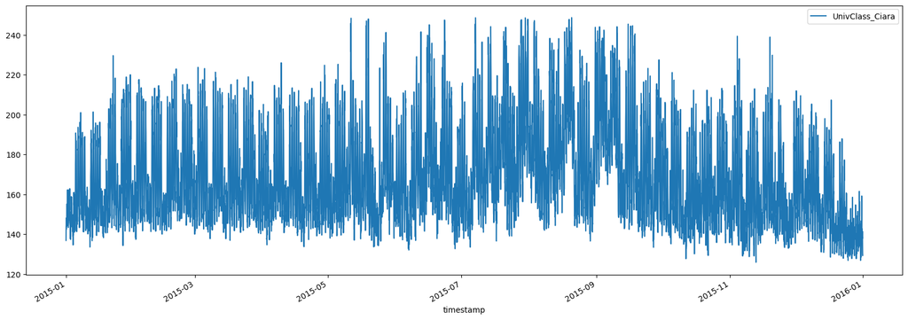

```python
df_prediction_data.plot()
```

```python
weather_data = pd.read_csv("./weather_data/weather2.csv", index_col='timestamp', parse_dates=True)
```

```python
weather_data.head()
```

| timestamp | Conditions | DateUTC<br /> | Dew PointC | Events | Gust SpeedKm/h | Humidity | Precipitationmm | Sea Level PressurehPa | TemperatureC | TimeEDT | TimeEST | VisibilityKm | Wind Direction | Wind SpeedKm/h | WindDirDegrees | timestamp.1 |
| --- | --- | --- | --- | --- | --- | --- | --- | --- | --- | --- | --- | --- | --- | --- | --- | --- |
| 2015-01-01 00:56:00 | Overcast | 2015-01-01 05:56:00<br /> | -15.0 | NaN | - | 54.0 | NaN | 1017.4 | -7.2 | NaN | 12:56 AM | 16.1 | SW | 18.5 | 230 | 2015-01-01 00:56:00 |
| 2015-01-01 01:56:00 | Overcast | 2015-01-01 06:56:00<br /> | -14.4 | NaN | - | 55.0 | NaN | 1017.2 | -6.6 | NaN | 1:56 AM | 16.1 | WSW | 14.8 | 240 | 2015-01-01 01:56:00 |
| 2015-01-01 02:56:00 | Overcast | 2015-01-01 07:56:00<br /> | -14.4 | NaN | - | 55.0 | NaN | 1016.9 | -6.6 | NaN | 2:56 AM | 16.1 | SW | 14.8 | 220 | 2015-01-01 02:56:00 |
| 2015-01-01 03:56:00 | Overcast | 2015-01-01 08:56:00<br /> | -14.4 | NaN | - | 55.0 | NaN | 1017.2 | -6.6 | NaN | 3:56 AM | 16.1 | SW | 18.5 | 220 | 2015-01-01 03:56:00 |
| 2015-01-01 04:56:00 | Overcast | 2015-01-01 09:56:00<br /> | -14.4 | NaN | - | 55.0 | NaN | 1017.2 | -6.6 | NaN | 4:56 AM | 16.1 | SSW | 14.8 | 210 | 2015-01-01 04:56:00 |

```python
weather_houly = weather_data.resample('H').mean(numeric_only=True)
weather_houly_nooutlier = weather_houly[weather_houly > -40]
weather_houly_nooutlier_nogaps = weather_houly_nooutlier.fillna(method='ffill')
```

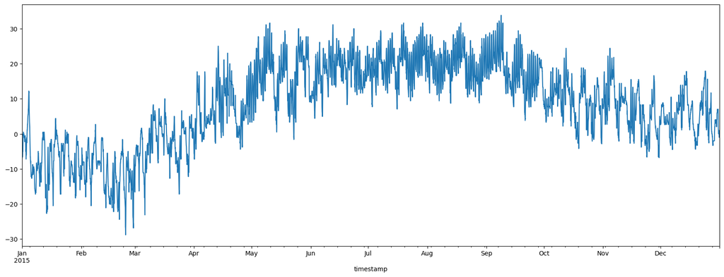

```python
temperature = weather_houly_nooutlier_nogaps['TemperatureC']
temperature.plot()
```

### Create Train and Test Datasets for Supervsed Learning

we will use 3 months of data from April, May, and June to prediction July.

```python
training_months = [4,5,6]
test_months = [7]
```

```python
trainingdata = df_prediction_data[df_prediction_data.index.month.isin(training_months)]
testdata = df_prediction_data[df_prediction_data.index.month.isin(test_months)]
```

```python
trainingdata.info()
```

```
<class 'pandas.core.frame.DataFrame'>
DatetimeIndex: 2184 entries, 2015-04-01 00:00:00 to 2015-06-30 23:00:00
Data columns (total 1 columns):
 #   Column           Non-Null Count  Dtype
---  ------           --------------  -----
 0   UnivClass_Ciara  2184 non-null   float64
dtypes: float64(1)
memory usage: 34.1 KB
```

```python
testdata.info()
```

```
<class 'pandas.core.frame.DataFrame'>
DatetimeIndex: 744 entries, 2015-07-01 00:00:00 to 2015-07-31 23:00:00
Data columns (total 1 columns):
 #   Column           Non-Null Count  Dtype
---  ------           --------------  -----
 0   UnivClass_Ciara  744 non-null    float64
dtypes: float64(1)
memory usage: 11.6 KB
```

### Encoding Categorical Variables

```python
train_features = pd.concat([pd.get_dummies(trainingdata.index.hour),
                                     pd.get_dummies(trainingdata.index.dayofweek),
                                     pd.DataFrame(temperature[temperature.index.month.isin(training_months)].values)], axis=1).dropna()
```

```python
train_features.head()
```

|  | 0 | 1 | 2 | 3 | 4 | 5 | 6 | 7 | 8 | 9 | ... | 22 | 23 | 0 | 1 | 2 | 3 | 4 | 5 | 6 | 0 |
| --- | --- | --- | --- | --- | --- | --- | --- | --- | --- | --- | --- | --- | --- | --- | --- | --- | --- | --- | --- | --- | --- |
| 0 | 1 | 0 | 0 | 0 | 0 | 0 | 0 | 0 | 0 | 0 | ... | 0 | 0 | 0 | 0 | 1 | 0 | 0 | 0 | 0 | -5.5 |
| 1 | 0 | 1 | 0 | 0 | 0 | 0 | 0 | 0 | 0 | 0 | ... | 0 | 0 | 0 | 0 | 1 | 0 | 0 | 0 | 0 | -6.1 |
| 2 | 0 | 0 | 1 | 0 | 0 | 0 | 0 | 0 | 0 | 0 | ... | 0 | 0 | 0 | 0 | 1 | 0 | 0 | 0 | 0 | -7.2 |
| 3 | 0 | 0 | 0 | 1 | 0 | 0 | 0 | 0 | 0 | 0 | ... | 0 | 0 | 0 | 0 | 1 | 0 | 0 | 0 | 0 | -6.6 |
| 4 | 0 | 0 | 0 | 0 | 1 | 0 | 0 | 0 | 0 | 0 | ... | 0 | 0 | 0 | 0 | 1 | 0 | 0 | 0 | 0 | -7.2 |

5 rows × 32 columns

```python
print(train_features.shape, trainingdata.shape)
```

```
(2184, 32) (2184, 1)
```

```python
model = KNeighborsRegressor()
model.fit(np.array(train_features), np.array(trainingdata.values))
```

```
KNeighborsRegressor()
```

```python
test_features = np.array(pd.concat([pd.get_dummies(testdata.index.hour),
                                    pd.get_dummies(testdata.index.dayofweek),
                                    pd.DataFrame(temperature[temperature.index.month.isin(test_months)].values)], axis=1).dropna())
```

```python
# predictions
preds = model.predict(test_features)
```

```python
predicted_vs_actual = pd.concat([testdata, pd.DataFrame(preds, index=testdata.index)], axis=1)
```

```python
predicted_vs_actual = preds_vs_actual.rename(columns={"UnivClass_Ciara":"Actual", 0: "Predicted"})
```

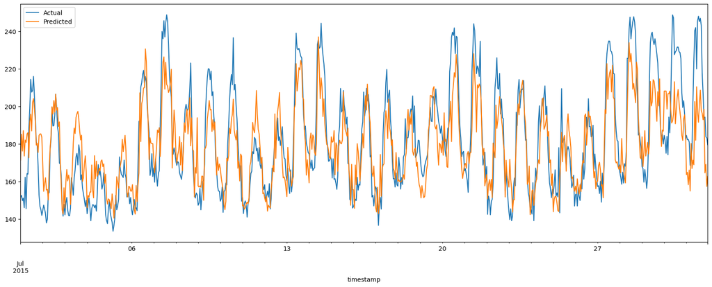

```python
preds_vs_actual.plot()
```

```python
trainingdata = trainingdata.rename(columns={"UnivClass_Ciara":"Actual"})
trainingdata.head()
```

| timestamp | Actual |
| --- | --- |
| 2015-04-01 00:00:00 | 145.500000 |
| 2015-04-01 01:00:00 | 141.775002 |
| 2015-04-01 02:00:00 | 158.499996 |
| 2015-04-01 03:00:00 | 142.849998 |
| 2015-04-01 04:00:00 | 145.550003 |

```python
predicted_vs_actual_training = pd.concat([trainingdata, preds_vs_actual], sort=True)
```

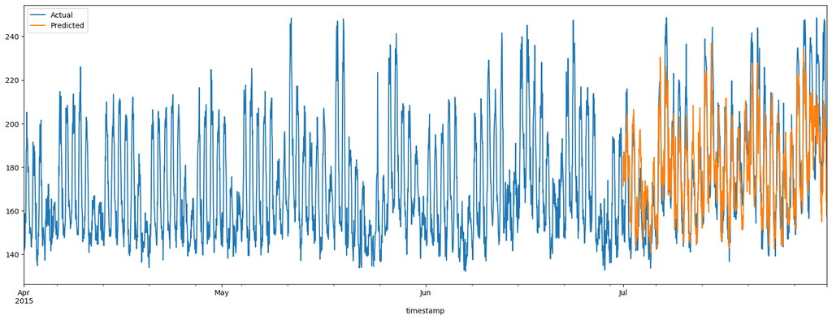

```python
predicted_vs_actual_training.plot()
```

### Evaluation Meterics

##### MAPE VS MSE

https://stats.stackexchange.com/questions/11636/the-difference-between-mse-and-mape#:~:text=MSE%20is%20scale%2Ddependent%2C%20MAPE,when%20percentages%20make%20no%20sense.

```python
error = abs(predicted_vs_actual['Actual'] - predicted_vs_actual['Predicted'])
MAPE = sklearn.metrics.mean_absolute_percentage_error(predicted_vs_actual['Actual'], predicted_vs_actual['Predicted'])
MAPE * 100
```

```
6.954645494388625
```

### Supervised Classification Models¶

```python
from sklearn import svm, datasets
from sklearn.model_selection import train_test_split
from sklearn.metrics import confusion_matrix
from sklearn.dummy import DummyClassifier
from sklearn.ensemble import RandomForestClassifier
from sklearn.metrics import classification_report, roc_curve, auc, precision_recall_curve
import joblib
from sklearn.model_selection import RandomizedSearchCV
from sklearn.feature_selection import SelectKBest
```

#### Load the IEQ (Indoor Environmental Quality) Data and find a classification objective

```python
ieq_data = pd.read_csv("./ashrae_thermal_comfort_database_2.csv", index_col='Unnamed: 0')
```

```python
ieq_data.head()
```

|  | Publication (Citation) | Year | Season | Climate | City | Country | Building type | Cooling startegy_building level | Sex | Thermal sensation | Clo | Met | Air temperature (C) | Relative humidity (%) | Air velocity (m/s) | ThermalSensation_rounded |
| --- | --- | --- | --- | --- | --- | --- | --- | --- | --- | --- | --- | --- | --- | --- | --- | --- |
| 2233 | Indraganti, Madhavi, et al. "Adaptive model of... | 2012.0 | Winter | Tropical wet savanna | Chennai | India | Office | Mixed Mode | Female | -2.0 | 0.75 | 1.0 | 25.2 | 64.0 | 0.1 | -2.0 |
| 2234 | Indraganti, Madhavi, et al. "Adaptive model of... | 2012.0 | Winter | Tropical wet savanna | Chennai | India | Office | Mixed Mode | Male | -1.0 | 0.64 | 1.0 | 25.2 | 64.0 | 0.1 | -1.0 |
| 2235 | Indraganti, Madhavi, et al. "Adaptive model of... | 2012.0 | Winter | Tropical wet savanna | Chennai | India | Office | Mixed Mode | Male | -2.0 | 0.64 | 1.0 | 25.2 | 64.0 | 0.1 | -2.0 |
| 2236 | Indraganti, Madhavi, et al. "Adaptive model of... | 2012.0 | Winter | Tropical wet savanna | Chennai | India | Office | Mixed Mode | Female | -2.0 | 0.75 | 1.0 | 25.2 | 64.0 | 0.1 | -2.0 |
| 2237 | Indraganti, Madhavi, et al. "Adaptive model of... | 2012.0 | Winter | Tropical wet savanna | Chennai | India | Office | Mixed Mode | Male | 0.0 | 0.72 | 1.0 | 25.2 | 64.0 | 0.1 | 0.0 |

```python
ieq_data.info()
```

```
<class 'pandas.core.frame.DataFrame'>
Int64Index: 43448 entries, 2233 to 104033
Data columns (total 16 columns):
 #   Column                           Non-Null Count  Dtype
---  ------                           --------------  -----
 0   Publication (Citation)           43448 non-null  object
 1   Year                             43448 non-null  float64
 2   Season                           43448 non-null  object
 3   Climate                          43448 non-null  object
 4   City                             43448 non-null  object
 5   Country                          43448 non-null  object
 6   Building type                    43448 non-null  object
 7   Cooling startegy_building level  43448 non-null  object
 8   Sex                              43448 non-null  object
 9   Thermal sensation                43448 non-null  float64
 10  Clo                              43448 non-null  float64
 11  Met                              43448 non-null  float64
 12  Air temperature (C)              43448 non-null  float64
 13  Relative humidity (%)            43448 non-null  float64
 14  Air velocity (m/s)               43448 non-null  float64
 15  ThermalSensation_rounded         43448 non-null  float64
dtypes: float64(8), object(8)
memory usage: 5.6+ MB
```

```python
ieq_data["ThermalSensation_rounded"].value_counts()
```

```
 0.0    19537
 1.0     8396
-1.0     7693
 2.0     3657
-2.0     2459
 3.0     1265
-3.0      441
Name: ThermalSensation_rounded, dtype: int64
```

#### Predict Thermal Sensation using a Random Forest Model

```python
list(ieq_data.columns)
```

```
['Publication (Citation)',
 'Year',
 'Season',
 'Climate',
 'City',
 'Country',
 'Building type',
 'Cooling startegy_building level',
 'Sex',
 'Thermal sensation',
 'Clo',
 'Met',
 'Air temperature (C)',
 'Relative humidity (%)',
 'Air velocity (m/s)',
 'ThermalSensation_rounded']
```

These features will be used by the model to try to predict ThermalSensation_rounded.

Several of the features are related to the building context (i.e.: Country, City), the environmental conditions (i.e.: Air Temperature (C), Relative humidity (%)) and personal factors (i.e.: Sex, Clo, etc.)

```python
feature_columns = [
 'Year',
 'Season',
 'Climate',
 'City',
 'Country',
 'Building type',
 'Cooling startegy_building level',
 'Sex',
 'Clo',
 'Met',
 'Air temperature (C)',
 'Relative humidity (%)',
 'Air velocity (m/s)']
```

```python
features = ieq_data[feature_columns]
features.info()
```

```
<class 'pandas.core.frame.DataFrame'>
Int64Index: 43448 entries, 2233 to 104033
Data columns (total 13 columns):
 #   Column                           Non-Null Count  Dtype
---  ------                           --------------  -----
 0   Year                             43448 non-null  float64
 1   Season                           43448 non-null  object
 2   Climate                          43448 non-null  object
 3   City                             43448 non-null  object
 4   Country                          43448 non-null  object
 5   Building type                    43448 non-null  object
 6   Cooling startegy_building level  43448 non-null  object
 7   Sex                              43448 non-null  object
 8   Clo                              43448 non-null  float64
 9   Met                              43448 non-null  float64
 10  Air temperature (C)              43448 non-null  float64
 11  Relative humidity (%)            43448 non-null  float64
 12  Air velocity (m/s)               43448 non-null  float64
dtypes: float64(6), object(7)
memory usage: 4.6+ MB
```

```python
target = ieq_data['ThermalSensation_rounded']
target.head()
```

```
2233   -2.0
2234   -1.0
2235   -2.0
2236   -2.0
2237    0.0
Name: ThermalSensation_rounded, dtype: float64
```

```python
features.head()
```

|  | Year | Season | Climate | City | Country | Building type | Cooling startegy_building level | Sex | Clo | Met | Air temperature (C) | Relative humidity (%) | Air velocity (m/s) |
| --- | --- | --- | --- | --- | --- | --- | --- | --- | --- | --- | --- | --- | --- |
| 2233 | 2012.0 | Winter | Tropical wet savanna | Chennai | India | Office | Mixed Mode | Female | 0.75 | 1.0 | 25.2 | 64.0 | 0.1 |
| 2234 | 2012.0 | Winter | Tropical wet savanna | Chennai | India | Office | Mixed Mode | Male | 0.64 | 1.0 | 25.2 | 64.0 | 0.1 |
| 2235 | 2012.0 | Winter | Tropical wet savanna | Chennai | India | Office | Mixed Mode | Male | 0.64 | 1.0 | 25.2 | 64.0 | 0.1 |
| 2236 | 2012.0 | Winter | Tropical wet savanna | Chennai | India | Office | Mixed Mode | Female | 0.75 | 1.0 | 25.2 | 64.0 | 0.1 |
| 2237 | 2012.0 | Winter | Tropical wet savanna | Chennai | India | Office | Mixed Mode | Male | 0.72 | 1.0 | 25.2 | 64.0 | 0.1 |

```python
features_withdummies = pd.get_dummies(features)
features_withdummies.head()
```

|  | Year | Clo | Met | Air temperature (C) | Relative humidity (%) | Air velocity (m/s) | Season_Autumn | Season_Spring | Season_Summer | Season_Winter | ... | Building type_Multifamily housing | Building type_Office | Building type_Others | Building type_Senior center | Cooling startegy_building level_Air Conditioned | Cooling startegy_building level_Mechanically Ventilated | Cooling startegy_building level_Mixed Mode | Cooling startegy_building level_Naturally Ventilated | Sex_Female | Sex_Male |
| --- | --- | --- | --- | --- | --- | --- | --- | --- | --- | --- | --- | --- | --- | --- | --- | --- | --- | --- | --- | --- | --- |
| 2233 | 2012.0 | 0.75 | 1.0 | 25.2 | 64.0 | 0.1 | 0 | 0 | 0 | 1 | ... | 0 | 1 | 0 | 0 | 0 | 0 | 1 | 0 | 1 | 0 |
| 2234 | 2012.0 | 0.64 | 1.0 | 25.2 | 64.0 | 0.1 | 0 | 0 | 0 | 1 | ... | 0 | 1 | 0 | 0 | 0 | 0 | 1 | 0 | 0 | 1 |
| 2235 | 2012.0 | 0.64 | 1.0 | 25.2 | 64.0 | 0.1 | 0 | 0 | 0 | 1 | ... | 0 | 1 | 0 | 0 | 0 | 0 | 1 | 0 | 0 | 1 |
| 2236 | 2012.0 | 0.75 | 1.0 | 25.2 | 64.0 | 0.1 | 0 | 0 | 0 | 1 | ... | 0 | 1 | 0 | 0 | 0 | 0 | 1 | 0 | 1 | 0 |
| 2237 | 2012.0 | 0.72 | 1.0 | 25.2 | 64.0 | 0.1 | 0 | 0 | 0 | 1 | ... | 0 | 1 | 0 | 0 | 0 | 0 | 1 | 0 | 0 | 1 |

5 rows × 102 columns

#### Create the Train and Test Split using Scikit-Learn library

```python
# X_train, X_test, y_train, y_test = train_test_split(
#     X, y, test_size=0.33, random_state=42)
features_train, features_test, target_train, target_test = train_test_split(features_withdummies, target, test_size=0.3, random_state=2)
```

```python
rf_model = RandomForestClassifier(n_estimators = 100, min_samples_leaf = 2, random_state = 2, max_features = 'auto', oob_score=True)
```

```python
rf_model
```

```
RandomForestClassifier(max_features='auto', min_samples_leaf=2, oob_score=True,
                       random_state=2)
```

```python
rf_model.fit(features_train, target_train)
```

```
RandomForestClassifier(max_features='auto', min_samples_leaf=2, oob_score=True,
                       random_state=2)
```

```python
mean_model_accuracy = rf_model.oob_score_

print("Model accuracy: "+str(mean_model_accuracy))
```

```
Model accuracy: 0.4872587380396541
```

#### Create a Baseline Model to compare the accuracy of the model¶

```python
#Dummy Classifier model to get a baseline
baseline_rf = DummyClassifier(strategy='stratified',random_state=0)
baseline_rf.fit(features_train, target_train)
#DummyClassifier(constant=None, random_state=1, strategy='most_frequent')
baseline_model_accuracy = baseline_rf.score(features_test, target_test)
print("Model accuracy: "+str(baseline_model_accuracy))
```

```
Model accuracy: 0.2833908707326429
```

#### Classification Report

```python
y_pred = rf_model.predict(features_test)
y_true = np.array(target_test)
print(classification_report(y_true, y_pred))
```

```
              precision    recall  f1-score   support

        -3.0       0.50      0.03      0.06       135
        -2.0       0.34      0.09      0.15       791
        -1.0       0.37      0.29      0.33      2252
         0.0       0.54      0.79      0.64      5863
         1.0       0.40      0.27      0.33      2499
         2.0       0.39      0.24      0.30      1079
         3.0       0.47      0.19      0.27       416

    accuracy                           0.49     13035
   macro avg       0.43      0.27      0.30     13035
weighted avg       0.46      0.49      0.45     13035
```

#### Feature Importance

```python
importances = rf_model.feature_importances_
# std = np.std([tree.feature_importances_ for tree in rf_model.estimators_], axis=0)
indices = np.argsort(importances)[::-1]
```

```python
# Print the feature ranking
print("Feature ranking:")

for f in range(features_withdummies.shape[1]):
    print("%d. feature %s (%f)" % (f + 1, features_withdummies.columns[indices[f]], importances[indices[f]]))
```

```
Feature ranking:
1. feature Air temperature (C) (0.227244)
2. feature Relative humidity (%) (0.192509)
3. feature Air velocity (m/s) (0.153570)
4. feature Clo (0.148443)
5. feature Met (0.069358)
6. feature Year (0.018625)
7. feature Sex_Female (0.016522)
8. feature Sex_Male (0.016083)
9. feature Season_Summer (0.011295)
10. feature Season_Winter (0.009701)
11. feature Season_Spring (0.007988)
12. feature Season_Autumn (0.007010)
13. feature Cooling startegy_building level_Air Conditioned (0.006721)
14. feature Cooling startegy_building level_Naturally Ventilated (0.006303)
15. feature Cooling startegy_building level_Mixed Mode (0.006215)
16. feature Climate_Tropical wet savanna (0.005513)
17. feature Building type_Office (0.004602)
18. feature Country_India (0.004321)
19. feature Climate_Hot semi-arid (0.004083)
20. feature City_Chennai (0.003510)
21. feature Climate_Subtropical highland (0.003073)
22. feature Building type_Others (0.002585)
23. feature City_Shimla (0.002564)
24. feature Building type_Classroom (0.002368)
25. feature Country_Australia (0.002255)
26. feature Country_UK (0.002091)
27. feature Climate_Humid subtropical (0.002077)
28. feature City_London (0.002061)
29. feature City_Jaipur (0.001996)
30. feature Building type_Multifamily housing (0.001977)
31. feature Country_Brazil (0.001842)
32. feature Country_Greece (0.001774)
33. feature Climate_Temperate oceanic (0.001710)
34. feature City_Delhi (0.001704)
35. feature City_Athens (0.001687)
36. feature Climate_Warm-summer humid continental (0.001645)
37. feature City_Hyderabad (0.001636)
38. feature Country_Sweden (0.001635)
39. feature City_Florianopolis (0.001520)
```

[output cut: 48 more lines]

```
88. feature Country_Italy (0.000246)
89. feature City_Malmo (0.000238)
90. feature City_Lisbon (0.000224)
91. feature City_Goulburn (0.000199)
92. feature City_Halmstad (0.000195)
93. feature City_Auburn (0.000193)
94. feature City_Varese (0.000163)
95. feature City_Putra Jaya (0.000133)
96. feature City_Bedong (0.000128)
97. feature City_Lodi (0.000107)
98. feature City_Imola (0.000104)
99. feature City_Beverly Hills (0.000054)
100. feature City_Kinarut (0.000039)
101. feature City_Kuching (0.000038)
102. feature City_Kuala Lumpur (0.000015)
```

#### Plot Importances

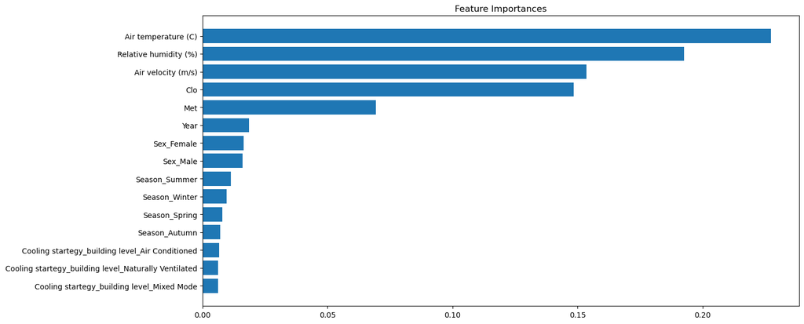

```python
# Plot the feature importances of the forest
plt.figure(figsize=(15,6))
plt.title("Feature Importances")
plt.barh(range(15), importances[indices][:15], align="center")
plt.yticks(range(15), features_withdummies.columns[indices][:15])#
plt.gca().invert_yaxis()
plt.tight_layout(pad=0.4)
plt.show()
```

```python
importances[indices][:15]
```

```
array([0.22724414, 0.19250949, 0.1535699 , 0.14844308, 0.06935753,
       0.01862525, 0.01652153, 0.01608305, 0.01129537, 0.00970149,
       0.00798764, 0.00701028, 0.00672132, 0.00630335, 0.00621502])
```

### Confusion Matrix Visualization

```python
sns.set(font_scale=1.4)
cm = confusion_matrix(y_true, y_pred)
np.set_printoptions(precision=2)
print('Confusion matrix, without normalization')
print(cm)
plt.figure(figsize=(12,10))
```

```
Confusion matrix, without normalization
[[   4   10   33   73   10    1    4]
 [   1   74  229  427   48    8    4]
 [   3   62  662 1363  135   23    4]
 [   0   46  570 4617  499  111   20]
 [   0   14  183 1438  683  163   18]
 [   0    9   70  453  249  259   39]
 [   0    5   32  123   71  105   80]]
```

```python
def plot_confusion_matrix(cm, categories, title='Confusion matrix', cmap='Reds'):
    plt.imshow(cm, interpolation='nearest', cmap=cmap)
    plt.title(title)
    plt.colorbar()
    tick_marks = np.arange(len(categories))
    plt.xticks(tick_marks,categories, rotation=90)
    plt.yticks(tick_marks,categories)
    plt.tight_layout()
    plt.ylabel('True label')
    plt.xlabel('Predicted label')
    plt.tight_layout()
```

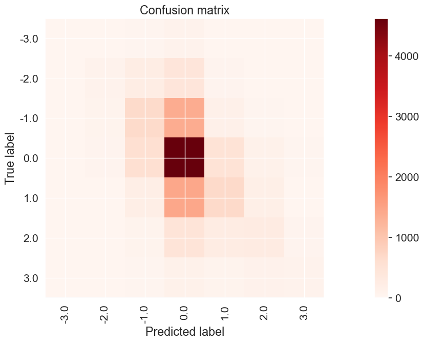

```python
categories = np.array(target.sort_values().unique())
plot_confusion_matrix(cm, categories)
```

[output not shown]

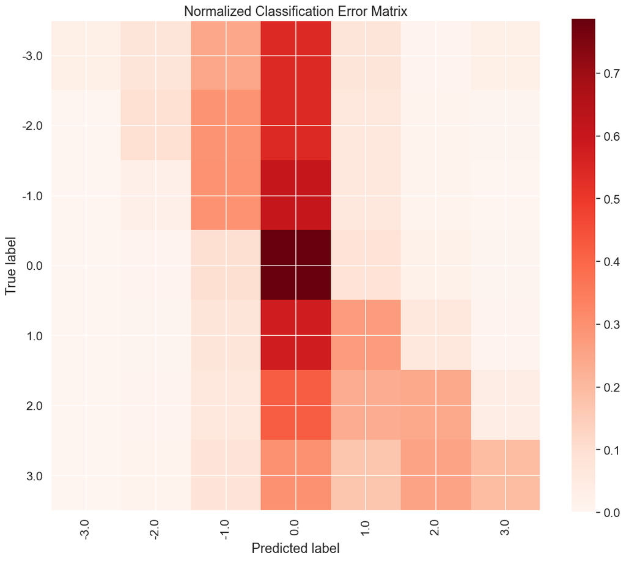

```python
cm_normalized = cm.astype('float') / cm.sum(axis=1)[:, np.newaxis]
print('Normalized confusion matrix')
print(cm_normalized)
plt.figure(figsize=(12,10))
plot_confusion_matrix(cm_normalized, categories, title='Normalized Classification Error Matrix')
plt.show()
```